# Outside Context Memory

> This notebook focuses on context memory outside the rooms.

# 1 Overview of the data

The rooms were separated into *Familiar* and *Novel* groups. Participants explored the *Familiar* group at the beginning of the experiment. In the encoding task, they visisted both *Familiar* and *Novel* groups. Their context memory (i.e., in which room they saw the item) was tested in the memory test the next day of the encoding task. **Novelty benefits** on the context memory are examined by comparing the memory performance between the *Familiar* and *Novel* groups.

Participants were also asked to rate how curious they felt about the room. The higher the rating is means they felt more curious about the room. Context memory as a function of curiosity rating was also examined for **curiosity benefits**.

Questionnaires on personal traits regarding curiosity were also administered to participants before the encoding task (i.e., PC and EC). Scores on these questionnaires might be able to predict the context memory or its relationship with curiosity rating.

In the encoding task, there were 6 objects outside each room. It is possbile that the context memory for the object to some extent depends on the order in which the object was seen. For example, it may be easier to remember where the first and last objects were seen as compared to those in the middle. Particularly, if the participant became more curious when getting closer to the room, then one would expect that the performance increases as a function of item order.

# 2 Individual performance

## 2.1 An overview of individual context memory performance as a function of room.

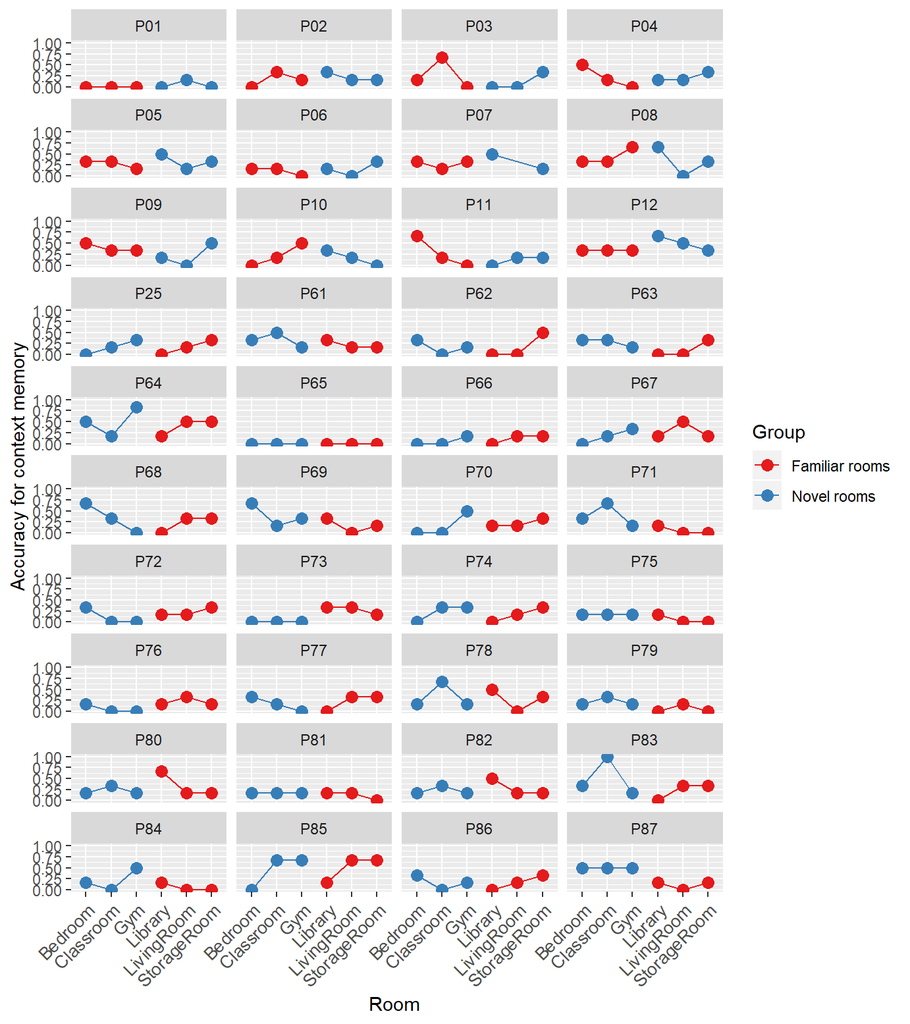

Figure 1. Mean accuracy for context memory respectively for each room and each individual participant.

# 3 Novelty Benefits

We predicted that the context memory should be better for the *novel* rooms than for the *familiar* rooms.

## 3.1 Compare mean accuracy between *novel* and *familiar* rooms

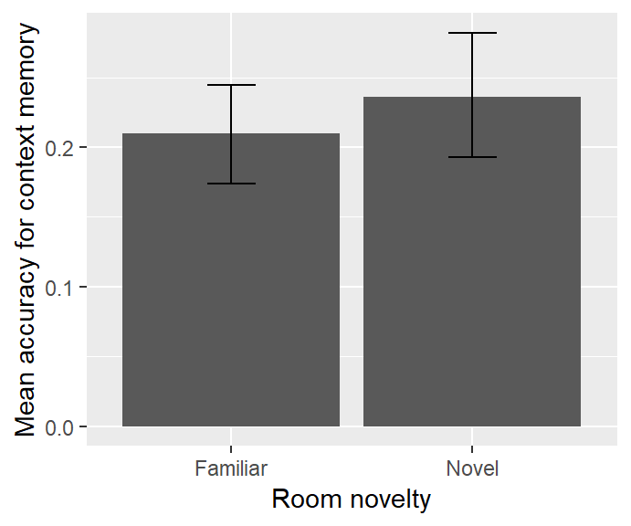

Figure 2. Mean accuracy for context memory respectively for Familiar and Novel rooms.

```
##
##  Paired t-test
##
## data:  MeanCorrContextAccuracy by Group
## t = -1.1636, df = 39, p-value = 0.2517
## alternative hypothesis: true difference in means is not equal to 0
## 95 percent confidence interval:
##  -0.07226224  0.01948447
## sample estimates:
## mean of the differences
##             -0.02638889
```

Unfortunately not significant.

## 3.2 Context memory as a function of item order

### 3.2.1 Visualise the data

#### 3.2.1.1 Nonlinear

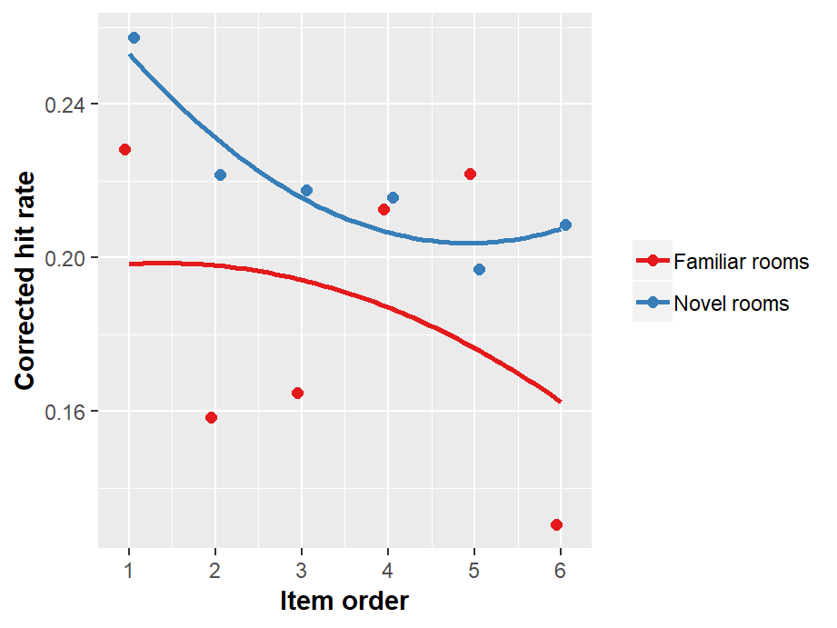

Figure 3. Mean accuracy of context memory for items at each order (i.e., 1st, 2nd, 3rd, etc), respectively for familiar and novel rooms.

#### 3.2.1.2 Linear

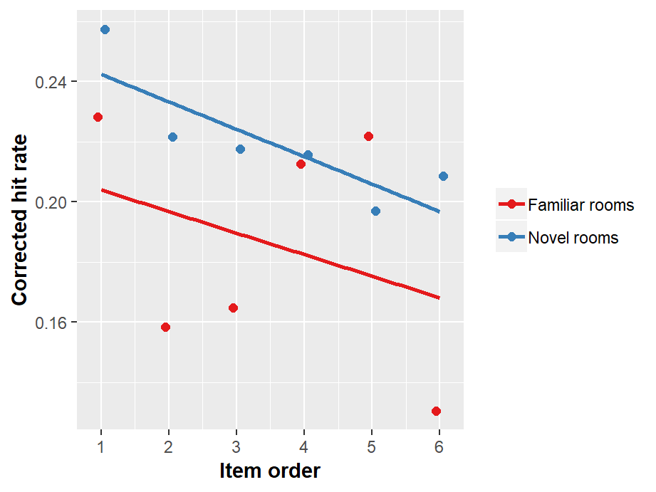

### 3.2.2 Testing novelty effect as a function of item order by fitting mixed models

Build models with context memory accuracy as $y$ and then examine effects of item order and novelty by comparing the models.

```
##                      Model df       AIC       BIC   logLik   Test
## baseline.context         1  4 -67.11864 -50.42350 37.55932
## order.model.linear.1     2  5 -67.16605 -46.29712 38.58303 1 vs 2
## novelty.model.1          3  6 -67.68417 -42.64146 39.84209 2 vs 3
## novelty.model.2          4  7 -65.71362 -36.49712 39.85681 3 vs 4
##                        L.Ratio p-value
## baseline.context
## order.model.linear.1 2.0474090  0.1525
## novelty.model.1      2.5181230  0.1125
## novelty.model.2      0.0294475  0.8637
```

### 3.2.3 Collapse the order

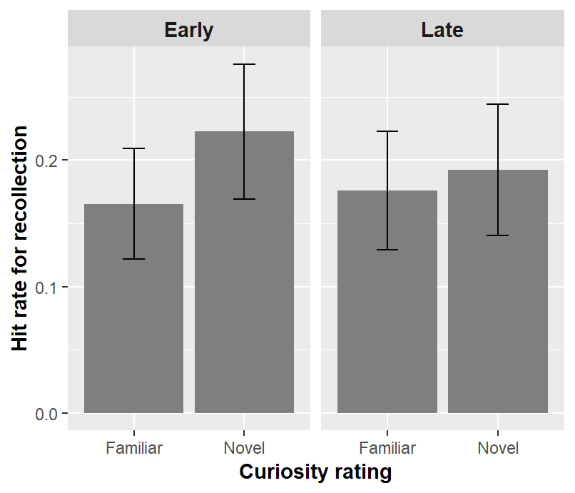

#### 3.2.3.1 Stats on it

```
##                  Model df       AIC       BIC   logLik   Test   L.Ratio
## baseline             1  5 -152.4846 -137.1087 81.24231
## noveltyModel         2  6 -153.4578 -135.0067 82.72889 1 vs 2 2.9731489
## orderModel           3  7 -151.6992 -130.1730 82.84960 2 vs 3 0.2414244
## interactionModel     4  8 -150.7677 -126.1663 83.38386 3 vs 4 1.0685153
##                  p-value
## baseline
## noveltyModel      0.0847
## orderModel        0.6232
## interactionModel  0.3013
```

```
##                                    Value  Std.Error DF    t-value
## (Intercept)                   0.16539352 0.02427062 78  6.8145560
## GroupNovel                    0.05717593 0.02908297 39  1.9659589
## ItemOrderTypeLate             0.01064815 0.02812998 78  0.3785338
## GroupNovel:ItemOrderTypeLate -0.04074074 0.03978180 78 -1.0241051
##                                   p-value
## (Intercept)                  1.771512e-09
## GroupNovel                   5.645125e-02
## ItemOrderTypeLate            7.060624e-01
## GroupNovel:ItemOrderTypeLate 3.089513e-01
```

No interaction. Novel > Familiar for the *early* group but failed to reach significance.

# 4 Curiosity Benefits

Here I checked how accurach of context memory changes as a function of curiosity rating. We hypothesised that the more curiosity the participant felt about the room (higher ratings) the better the context memory.

## 4.1 Mean accuracy of context memory as a function of curiosity rating

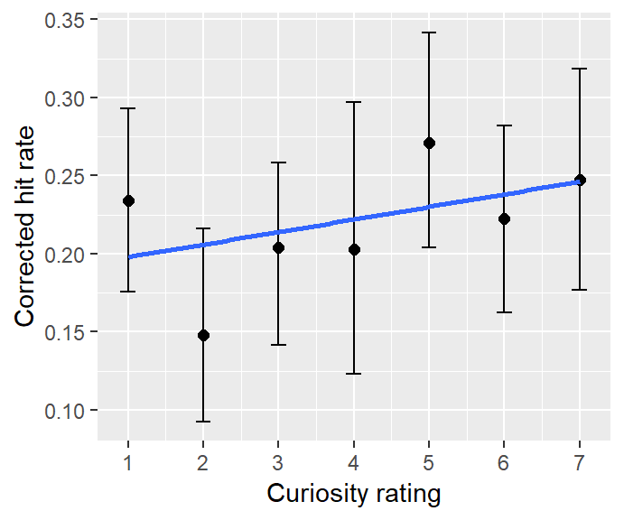

Figure 5. Mean accuracy for context memory as a function of curiosity rating.

### 4.1.1 Testing the relationship between mean accuracy of context memory and curiosity rating

Build models with context memory accuracy as $y$ and cexamine effects of curiosity rating by including it into the model and then comparing the model fits.

- `baseline.rating` is the model with only an intercept, showing no change in context memory as a function of curiosity rating.
- `rating.intercept` is the model with $\small CuriosityRating$ included, showing the effects of curiosity rating.
- `rating.slope` is the model allowing the slope (i.e., relationship between context memory and curiosity rating) varying across participants.

```
##                  Model df       AIC       BIC   logLik   Test   L.Ratio
## baseline.rating      1  3 -92.23539 -81.80600 49.11770
## rating.intercept     2  4 -92.50651 -78.60066 50.25326 1 vs 2 2.2711199
## rating.slope         3  6 -88.50577 -67.64699 50.25289 2 vs 3 0.0007403
##                  p-value
## baseline.rating
## rating.intercept  0.1318
## rating.slope      0.9996
```

#### 4.1.1.1 Parameter estimates in the complete model

```r
summary(rating.intercept)$tTable
```

```
##                       Value   Std.Error  DF  t-value      p-value
## (Intercept)     0.185262935 0.029713667 198 6.234940 2.676664e-09
## CuriosityRating 0.009209827 0.006103176 198 1.509022 1.328872e-01
```

### 4.1.2 Using normalised curiosity ratings.

```
##                  Model df       AIC       BIC  logLik   Test   L.Ratio
## baseline.rating      1  3 -92.23539 -81.80600 49.1177
## rating.intercept     2  4 -92.46099 -78.55514 50.2305 1 vs 2 2.2255984
## rating.slope         3  6 -88.45980 -67.60102 50.2299 2 vs 3 0.0011923
##                  p-value
## baseline.rating
## rating.intercept  0.1357
## rating.slope      0.9994
```

```r
summary(rating.intercept)$tTable
```

```
##                       Value  Std.Error  DF  t-value      p-value
## (Intercept)      0.22258634 0.01634101 198 13.62133 3.026822e-30
## NCuriosityRating 0.01978191 0.01327868 198  1.48975 1.378811e-01
```

## 4.2 Does the relationship with curiosity rating depend on item order?

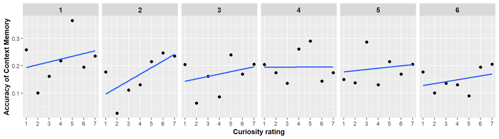

Figure 6. Mean accuracy across participants for context memory as a function of curiosity rating for each order at which the item was seen (I.e., 1st, 2nd, 3rd, etc.).

### 4.2.1 Testing the effect of item order

Build models with context memory accuracy as $y$ and examine effects of curioity rating and item order by comparing the models.

- `item.model.linear.1` is the model with $\small ItemOrder$ included (in addition to $\small CuriosityRating$), showing the effects of item order.
- `item.model.linear.2` is the model allowing the slope (i.e., relationship between context memory and item order) varying across participants.
- `item.model.linear.3` is the model with the interaction between $\small ItemOrders$ and $\small CuriosityRating$ included.
- `item.model.quad.1` and `item.model.quad.2` repectively included $\small ItemOrder^2$ and related random effects.
- `item.model.quad.3` included interaction between $\small ItemOrder^2$ and $\small CuriosityRating$ for inestigating whether the pattern changes as a function of *curiosity rating*.

```r
baseline.context <- lme(CorrContextAccuracy ~ 1, random = ~ 1|SubjectNo, data = Curiosity.Recall.Old, method = "ML", control = list(msMaxIter = 500, opt = "optim", msVerbose=FALSE), na.action = na.exclude)

rating.intercept <- update(baseline.context, .~. + CuriosityRating)
rating.slope     <- update(rating.intercept, random = ~ 1 + CuriosityRating | SubjectNo)

item.model.linear.1     <- update(rating.slope, .~. + ItemOrder)
# item.model.linear.2     <- update(item.model.linear.1, random = list(~1+CuriosityRating|SubjectNo, ~1+ItemOrder|SubjectNo))
item.model.linear.3     <- update(item.model.linear.1, .~. + ItemOrder : CuriosityRating)

# item.model.quad.1       <- update(item.model.linear.3, .~. + I(ItemOrder^2))
# item.model.quad.2       <- update(item.model.quad.1,   random = list(~1+CuriosityRating|SubjectNo, ~1+ItemOrder+I(ItemOrder^2)|SubjectNo)) # excluding this model because singularity issue (perhaps the model was getting too complex to be calculated)
# item.model.quad.3       <- update(item.model.quad.1,   .~. + I(ItemOrder^2) : CuriosityRating)

anova(baseline.context, rating.intercept, rating.slope, item.model.linear.1, item.model.linear.3)
```

```
##                     Model df      AIC      BIC    logLik   Test  L.Ratio
## baseline.context        1  3 1571.651 1587.456 -782.8257
## rating.intercept        2  4 1569.875 1590.948 -780.9375 1 vs 2 3.776396
## rating.slope            3  6 1572.941 1604.551 -780.4706 2 vs 3 0.933768
## item.model.linear.1     4  7 1573.255 1610.132 -779.6275 3 vs 4 1.686274
## item.model.linear.3     5  8 1574.676 1616.822 -779.3382 4 vs 5 0.578612
##                     p-value
## baseline.context
## rating.intercept     0.0520
## rating.slope         0.6270
## item.model.linear.1  0.1941
## item.model.linear.3  0.4469
```

No significant effect, although curiosity rating is close to significance, *p* = 0.052.

#### 4.2.1.1 What about **normalised ratings**?

```r
baseline.context <- lme(CorrContextAccuracy ~ 1, random = ~ 1|SubjectNo, data = Curiosity.Recall.Old, method = "ML", control = list(msMaxIter = 500, opt = "optim", msVerbose=FALSE), na.action = na.exclude)

rating.intercept <- update(baseline.context, .~. + NCuriosityRating)
rating.slope     <- update(rating.intercept, random = ~ 1 + NCuriosityRating | SubjectNo)

item.model.linear.1     <- update(rating.slope, .~. + ItemOrder)
# item.model.linear.2     <- update(item.model.linear.1, random = list(~1+CuriosityRating|SubjectNo, ~1+ItemOrder|SubjectNo))
item.model.linear.3     <- update(item.model.linear.1, .~. + ItemOrder : NCuriosityRating)

# item.model.quad.1       <- update(item.model.linear.3, .~. + I(ItemOrder^2))
# item.model.quad.2       <- update(item.model.quad.1,   random = list(~1+CuriosityRating|SubjectNo, ~1+ItemOrder+I(ItemOrder^2)|SubjectNo)) # excluding this model because singularity issue (perhaps the model was getting too complex to be calculated)
# item.model.quad.3       <- update(item.model.quad.1,   .~. + I(ItemOrder^2) : CuriosityRating)

anova(baseline.context, rating.intercept, rating.slope, item.model.linear.1, item.model.linear.3)
```

```
##                     Model df      AIC      BIC    logLik   Test  L.Ratio
## baseline.context        1  3 1571.651 1587.456 -782.8257
## rating.intercept        2  4 1569.845 1590.918 -780.9225 1 vs 2 3.806470
## rating.slope            3  6 1572.414 1604.024 -780.2072 2 vs 3 1.430569
## item.model.linear.1     4  7 1572.729 1609.606 -779.3643 3 vs 4 1.685769
## item.model.linear.3     5  8 1573.747 1615.892 -778.8734 4 vs 5 0.981845
##                     p-value
## baseline.context
## rating.intercept     0.0511
## rating.slope         0.4891
## item.model.linear.1  0.1942
## item.model.linear.3  0.3217
```

The same.

### 4.2.2 Collapse the order and curiosity rating

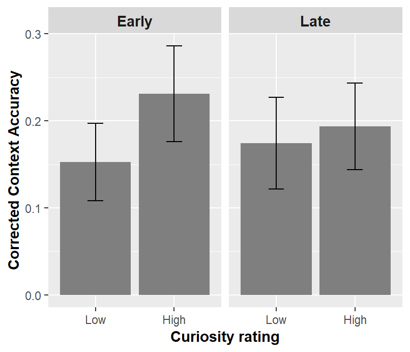

Figure 7. Mean hit rate as a function of item order (Early vs. Late) and curiosity (Low vs. High).

#### 4.2.2.1 Stats on it

```
##                  Model df       AIC       BIC   logLik   Test  L.Ratio
## baseline             1  5 -139.0294 -123.7801 74.51468
## curiosityModel       2  6 -142.1413 -123.8422 77.07065 1 vs 2 5.111932
## orderModel           3  7 -140.3173 -118.9683 77.15865 2 vs 3 0.176002
## interactionModel     4  8 -140.3452 -115.9464 78.17260 3 vs 4 2.027907
##                  p-value
## baseline
## curiosityModel    0.0238
## orderModel        0.6748
## interactionModel  0.1544
```

```
##                              Value  Std.Error DF  t-value      p-value
## (Intercept)             0.16250931 0.02017690 78 8.054227 7.388627e-12
## CuriosityRatingTypeHigh 0.04975921 0.02138626 37 2.326690 2.556410e-02
```

A main effect of curiosity rating, but no interaction.

### 4.2.3 Try another way to calculate “High” and “Low” curiosity groups

> “High” - higher than mean; “Low” - lower than mean

#### 4.2.3.1 Compare “High” and “Low” groups

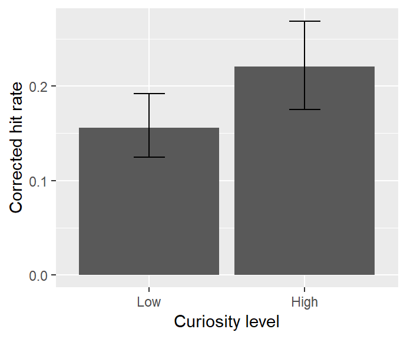

```
##
##  Paired t-test
##
## data:  CorrContextAccuracy by RatingGroup
## t = -2.8613, df = 39, p-value = 0.006749
## alternative hypothesis: true difference in means is not equal to 0
## 95 percent confidence interval:
##  -0.11033702 -0.01894538
## sample estimates:
## mean of the differences
##              -0.0646412
```

Significant.

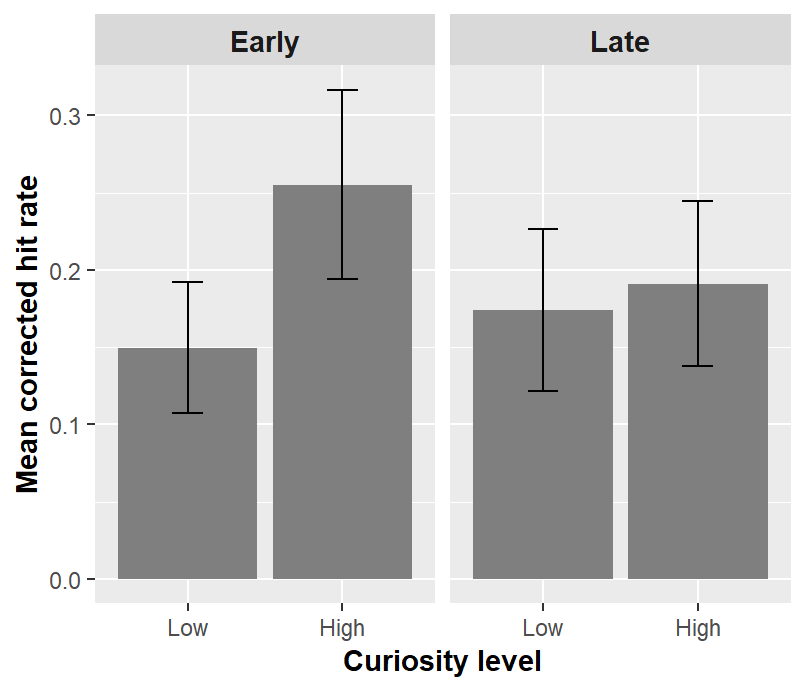

#### 4.2.3.2 Stats on it

```
##                  Model df       AIC        BIC   logLik   Test  L.Ratio
## baseline             1  5 -117.4504 -102.07455 63.72521
## curiosityModel       2  6 -122.4492 -103.99813 67.22458 1 vs 2 6.998754
## orderModel           3  7 -121.2127  -99.68651 67.60636 2 vs 3 0.763554
## interactionModel     4  8 -123.1015  -98.50008 69.55074 3 vs 4 3.888749
##                  p-value
## baseline
## curiosityModel    0.0082
## orderModel        0.3822
## interactionModel  0.0486
```

A main effect of curiosity and a significant interaction.

```
##
##   Simultaneous Tests for General Linear Hypotheses
##
## Fit: lme.formula(fixed = CorrContextAccuracy ~ RatingGroup + ItemOrderType +
##     RatingGroup:ItemOrderType, data = Curiosity.Recall.Old.Order.CuriosityType.MeanSep,
##     random = ~1 | SubjectNo/RatingGroup/ItemOrderType, method = "ML",
##     control = list(msMaxIter = 500, opt = "optim", msVerbose = FALSE))
##
## Linear Hypotheses:
##                        Estimate Std. Error z value Pr(>|z|)
## Early: High - Low == 0  0.10544    0.03151   3.346  0.00082 ***
## Late:  High - Low == 0  0.01684    0.03151   0.534  0.59307
## ---
## Signif. codes:  0 '***' 0.001 '**' 0.01 '*' 0.05 '.' 0.1 ' ' 1
## (Adjusted p values reported -- none method)
```

High > Low significantly for *early* group.

# 5 Curiosity and novelty

## 5.1 Testing the effects of curiosity rating and novelty together

Build models with context memory accuracy as $y$ and examine effects of curiosity rating and novelty together by including them into the model separately and then comparing the model fits.

- `baseline.rating` is the model with only an intercept, showing no change in context memory as a function of curiosity rating.
- `rating.intercept` is the model with $\small CuriosityRating$ included, showing the effects of curiosity rating.
- `rating.slope` is the model allowing the slope (i.e., relationship between context memory and curiosity rating) varying across participants.
- `novelty.model` is the model with $\small Group$ (i.e., *familiar* and *novel* rooms) included, examining the effects of novelty of the rooms on the intercept (i.e., mean context memory accuracy at the 1st order or overall if no difference in slope).
- `interaction.model` is the model with interaction between $\small Group$ and $\small CuriosityRating$ included, examining the effects of novelty on how context memory accuracy changes as a function of item order.

```
##                   Model df       AIC       BIC   logLik   Test   L.Ratio
## baseline.rating       1  4 -90.23490 -76.32905 49.11745
## rating.intercept      2  5 -90.50330 -73.12098 50.25165 1 vs 2 2.2683944
## novelty.model.1       3  6 -88.70161 -67.84283 50.35080 2 vs 3 0.1983124
## interaction.model     4  7 -86.83038 -62.49514 50.41519 3 vs 4 0.1287748
##                   p-value
## baseline.rating
## rating.intercept   0.1320
## novelty.model.1    0.6561
## interaction.model  0.7197
```

## 5.2 What about the other way around

```
##                   Model df      AIC      BIC    logLik   Test   L.Ratio
## baseline.context      1  3 1571.651 1587.456 -782.8257
## novelty.model.1       2  4 1570.497 1591.570 -781.2487 1 vs 2 3.1539885
## rating.model.1        3  5 1570.848 1597.189 -780.4238 2 vs 3 1.6497733
## rating.model.2        4 10 1579.960 1632.643 -779.9803 3 vs 4 0.8871183
## interaction.model     5 11 1581.697 1639.648 -779.8485 4 vs 5 0.2634274
##                   p-value
## baseline.context
## novelty.model.1    0.0757
## rating.model.1     0.1990
## rating.model.2     0.9711
## interaction.model  0.6078
```

## 5.3 Check the collapsed data

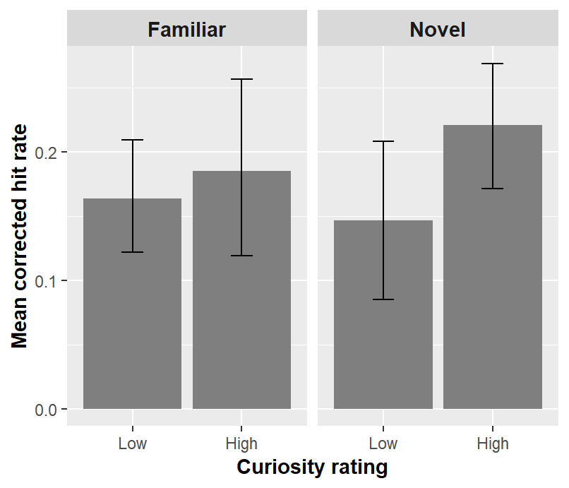

#### 5.3.0.1 Stats on it

```
##                  Model df       AIC       BIC   logLik   Test  L.Ratio
## baseline             1  5 -103.0736 -90.25190 56.53682
## curiosityModel       2  6 -106.1916 -90.80553 59.09581 1 vs 2 5.117981
## noveltyModel         3  7 -104.2383 -86.28790 59.11917 2 vs 3 0.046715
## interactionModel     4  8 -102.7497 -82.23489 59.37484 3 vs 4 0.511344
##                  p-value
## baseline
## curiosityModel    0.0237
## noveltyModel      0.8289
## interactionModel  0.4746
```

```
##                                  Value  Std.Error DF    t-value
## (Intercept)                 0.16356736 0.02359329 39  6.9327900
## RatingGroupHigh             0.03340650 0.03891727 39  0.8583977
## GroupNovel                 -0.01450078 0.03740685 14 -0.3876503
## RatingGroupHigh:GroupNovel  0.03951381 0.05632131 14  0.7015783
##                                 p-value
## (Intercept)                2.650679e-08
## RatingGroupHigh            3.959180e-01
## GroupNovel                 7.041047e-01
## RatingGroupHigh:GroupNovel 4.944405e-01
```

# 6 Curiosity effects in the *Novel* group

## 6.1 Mean accuracy of item memory as a function of curiosity rating

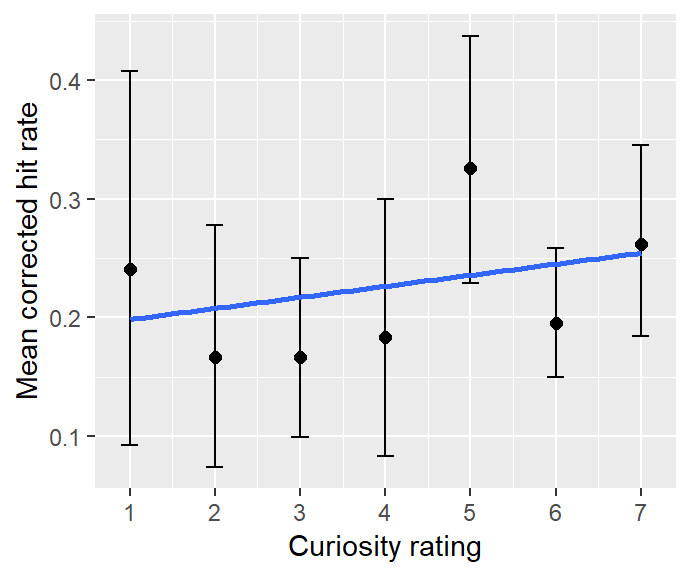